# GeoFencing and Click Through rates in Mobile Analytics

The purpose of the project is to understand what are the key parameters and factors driving Click through rate in Mobile devices. Is it the location or size of advertisement or the category of app that makes a difference? Read throught to understand.

```r
library(car, warn.conflicts = FALSE)             #For VIF Function
library(caret, warn.conflicts = FALSE)           #For Data imputation using KNN
library(corrplot, warn.conflicts = FALSE)        #For Correlation plot
library(ggplot2, warn.conflicts = FALSE)         #For Plotting graphs
library(dplyr, warn.conflicts = FALSE)           #For Data PreProcessing
library(aspace, warn.conflicts = FALSE)          #For Latitude to Radiance
library(DMwR,warn.conflicts = FALSE)             #For KNN Imputation
library(tidyr)                                   #For the gather function in ggplot
library(psych)                                   #For Descriptive statisticslibrary(ROCR)
library(regclass)                                #For Predicting the Confusion Matrix
library(ROCR)                                    #For Prediction and ROC Curve.
library(mapproj)                                 #For Getting a map output
```

## Data Importing:

We shift the working directory to our local path and import the 'Geo-Fence Analytics.csv' file as a data frame. We also read the record count of the data from the csv and check the number of missing values. We find that the app publisher name, os the device is running on, zip code and the app category have missing values.

```r
getwd()
setwd("C:/Users/Nijanth Anand/Downloads/BANA277-Customer Analytics/Assignment - Mobile Analytics")
data=read.csv("Geo-Fence Analytics.csv",header = TRUE,na.strings=c(""," ","NA"))
print(paste("The data from the Geo-Fence Analytics.csv file has been loaded"))
print(paste("Number of rows    :",nrow(data)))
print(paste("Number of columns :",ncol(data)))
```

'C:/Users/Nijanth Anand'

```
[1] "The data from the Geo-Fence Analytics.csv file has been loaded"
[1] "Number of rows    : 121567"
[1] "Number of columns : 15"
```

We store a backup of the data from the csv file before we proceed further.

```r
data_backup <- data
```

# Data Preperation

Since the data is now available as a data frame we go ahead with the data preperation.

### Null Value Treatment

We run the sapply function to check the NA value count in the records of the dataframe.

```r
print("Number of missing records in each column is")
sapply(data, function(x) sum(is.na(x)))
```

```
[1] "Number of missing records in each column is"
```

**imp_size**

0

**app_id**

0

**app_name**

0

**app_pub**

19654

**app_topcat**

3169

**app_review_vol**

0

**app_review_val**

0

**device_lat**

0

**device_lon**

0

**device_zip**

2799

**device_os**

687

**geofence_lat**

0

**geofence_lon**

0

**gepfence_radius**

0

**didclick**

0

We remove the app publisher and device zip attributes as they have high NA's and we have latitude and longitude, app category details to supplement the 2 attributes. For the rest of the missing values we run a knn imputation with a n value of 10 so it can do the imputation with 10 nearest neighbours based on the Eigen distance.

```r
data$app_pub<- NULL
data$device_zip<- NULL
data<-knnImputation(data,k=10)
```

### Feature Engineering

```
          1.imp_large         2. cat_entertainment       3.cat_social          4.cat_tech
          5.os_ios            6. distance(in kms)        7.distance_squared    8.ln_app_review_vol
```

```r
data <- mutate(data, imp_large = ifelse((data$imp_size=="728x90"), 1, 0))
data <- mutate(data, cat_entertainment=ifelse((data$app_topcat=="IAB1") | (data$app_topcat=="IAB1-6"),1,0))
data <- mutate(data, cat_social=ifelse((data$app_topcat=="IAB14"),1,0))
data <- mutate(data, cat_tech=ifelse((data$app_topcat=="IAB19-6"),1,0))
data <- mutate(data, os_ios=ifelse((data$device_os=='iOS'),1,0))
data <- mutate(data, ln_app_review_vol=log(data$app_review_vol))
data$device_lat=as_radians(data$device_lat)
data$device_lon=as_radians(data$device_lon)
data$geofence_lat=as_radians(data$geofence_lat)
data$geofence_lon=as_radians(data$geofence_lon)
data <- mutate(data, distance=acos( sin(data$device_lat)*sin(data$geofence_lat) + cos(data$device_lat)*cos(data$geofence_lat)*cos(data$device_lon-data$geofence_lon) ) * 6371)
#head(data$distance)
data <- mutate(data, distance_group = cut(distance, breaks = c(0,0.5,1,2,4,7,10,Inf), labels = c(1,2,3,4,5,6,7)))
data$distance_group <- as.integer(data$distance_group)
data <- mutate(data, distance_squared=(data$distance)^2)
```

## Data Interpretation and Data Visualisation - Descriptive Statistics

### Feature Selection

We only select the below features as stated in the question.

```
1. didclick       2. distance       3. imp_large             4. cat_entertainment    5. cat_social
6. cat_tech       7. os_ios         8. ln_app_review_vol     9.app_review_val
```

We create a new dataframe data1 and assign the values to it. The new dataa frame has 121,567 observations and 10 variables.

```r
data1 <- select(data,didclick,imp_large,cat_tech,cat_entertainment,cat_social,ln_app_review_vol,app_review_val,os_ios,distance_group,distance_squared)
str(data1)
```

```
'data.frame':	121567 obs. of  10 variables:
 $ didclick         : int  0 0 0 0 0 0 0 0 0 0 ...
 $ imp_large        : num  0 0 0 0 0 0 0 0 0 0 ...
 $ cat_tech         : num  0 0 0 0 0 0 0 0 0 0 ...
 $ cat_entertainment: num  0 0 0 0 0 0 0 0 0 0 ...
 $ cat_social       : num  0 0 0 0 0 0 0 0 0 0 ...
 $ ln_app_review_vol: num  11.1 11.1 11.1 11.1 11.1 ...
 $ app_review_val   : num  4.6 4.6 4.6 4.6 4.6 4.6 4.6 4.6 4.6 4.6 ...
 $ os_ios           : num  0 0 0 0 0 0 0 0 0 0 ...
 $ distance_group   : int  4 4 5 4 4 5 4 2 4 4 ...
 $ distance_squared : num  7.28 5.88 25.52 4.42 4.39 ...
```

### Descriptive Statistics

We now calculate the summary statistics for the data using mean, median, standard deviation, minimum, maximum, skewness and Kurtosis.

We also plot the histogram distribution of the numeric variables.

|  | vars | n | mean | sd | median | trimmed | mad | min | max | range | skew | kurtosis | se |
| --- | --- | --- | --- | --- | --- | --- | --- | --- | --- | --- | --- | --- | --- |
| didclick | 1 | 121567 | 0.006811059 | 0.08224794 | 0.00000 | 0.00000000 | 0.000000 | 0.0000000000 | 1.0000 | 1.000000 | 11.99263761 | 141.8245234 | 0.0002358942 |
| imp_large | 2 | 121567 | 0.230876800 | 0.42139550 | 0.00000 | 0.16360084 | 0.000000 | 0.0000000000 | 1.0000 | 1.000000 | 1.27728459 | -0.3685471 | 0.0012085985 |
| cat_tech | 3 | 121567 | 0.543914056 | 0.49806987 | 1.00000 | 0.55489178 | 0.000000 | 0.0000000000 | 1.0000 | 1.000000 | -0.17633548 | -1.9689220 | 0.0014285072 |
| cat_entertainment | 4 | 121567 | 0.283925736 | 0.45090308 | 0.00000 | 0.22991106 | 0.000000 | 0.0000000000 | 1.0000 | 1.000000 | 0.95839881 | -1.0814806 | 0.0012932287 |
| cat_social | 5 | 121567 | 0.125124417 | 0.33086130 | 0.00000 | 0.03141227 | 0.000000 | 0.0000000000 | 1.0000 | 1.000000 | 2.26604020 | 3.1349640 | 0.0009489386 |
| ln_app_review_vol | 6 | 121567 | 10.056798904 | 0.63696194 | 10.08722 | 9.98384595 | 0.000000 | 7.0808678967 | 12.9377 | 5.856834 | 1.78926780 | 6.1773255 | 0.0018268615 |
| app_review_val | 7 | 121567 | 3.654872622 | 0.36081251 | 3.40000 | 3.62465889 | 0.000000 | 1.4000000000 | 4.7000 | 3.300000 | 0.01724566 | 1.9459931 | 0.0010348413 |
| os_ios | 8 | 121567 | 0.250363997 | 0.43322443 | 0.00000 | 0.18795949 | 0.000000 | 0.0000000000 | 1.0000 | 1.000000 | 1.15244631 | -0.6718730 | 0.0012425249 |
| distance_group | 9 | 121567 | 3.622257685 | 1.44165407 | 4.00000 | 3.55299985 | 1.482600 | 1.0000000000 | 7.0000 | 6.000000 | 0.32416543 | -0.2702810 | 0.0041347877 |
| distance_squared | 10 | 121567 | 15.917320648 | 27.39226296 | 4.08389 | 8.66358915 | 5.365952 | 0.0004309338 | 138.9254 | 138.924990 | 2.48694671 | 5.5564938 | 0.0785633624 |

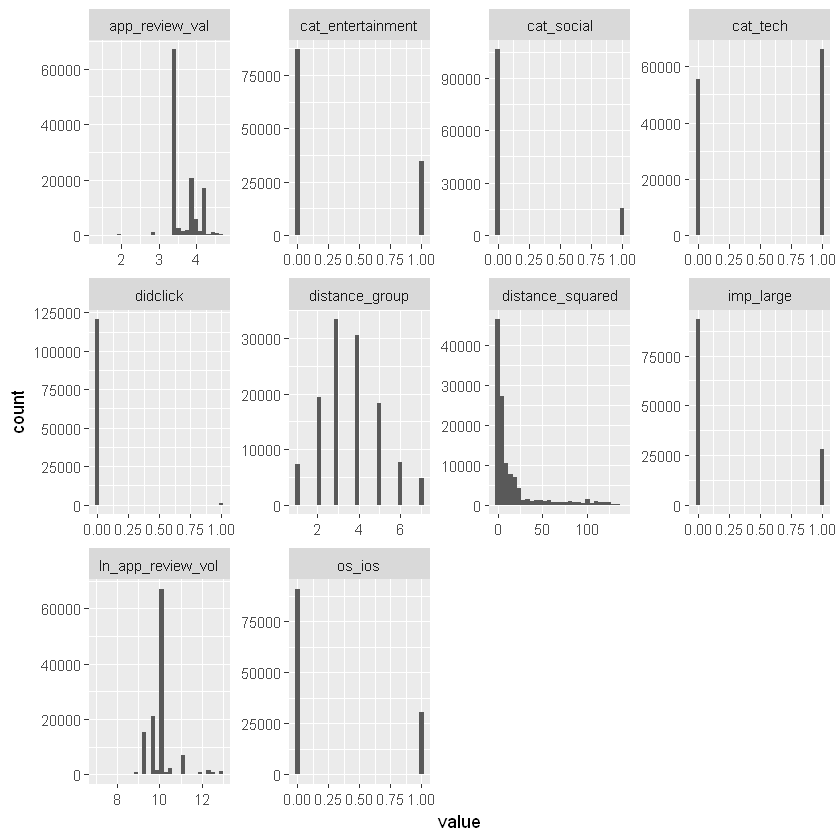

```r
psych::describe(data1,check=FALSE)             #Descriptive statistics #psych::describe(data1) %>% [,c(2,3,5,8,9,10,11,12)]
dplyr::select_if(data1,is.numeric) %>%
  gather() %>%
  ggplot(aes(value)) +
  facet_wrap(~ key, scales = "free") + scale_fill_gradient(low = "red",high = "yellow") +
  geom_histogram(bins=30)
```

### Correlation Amongst variables

We generate the correlation values amongst the numeric variables below using the pearson, kendall and spearman methods.

```r
#xyz<- rcorr(as.matrix(data1), type="spearman")
M=cor(data1,method = c("pearson", "kendall", "spearman"))
M
```

|  | didclick | imp_large | cat_tech | cat_entertainment | cat_social | ln_app_review_vol | app_review_val | os_ios | distance_group | distance_squared |
| --- | --- | --- | --- | --- | --- | --- | --- | --- | --- | --- |
| didclick | 1.000000000 | -0.004786218 | 0.012176592 | -0.007117972 | -0.005623417 | 0.003982875 | -0.006523592 | -0.002147325 | -0.007994014 | -0.004462031 |
| imp_large | -0.004786218 | 1.000000000 | 0.386715220 | -0.254731873 | -0.185311155 | 0.049929790 | -0.321439020 | -0.190194050 | 0.003670761 | 0.029075052 |
| cat_tech | 0.012176592 | 0.386715220 | 1.000000000 | -0.687646354 | -0.412990139 | 0.046101406 | -0.756895005 | -0.609490680 | -0.006483263 | 0.018865105 |
| cat_entertainment | -0.007117972 | -0.254731873 | -0.687646354 | 1.000000000 | -0.238133905 | -0.105545185 | 0.642212363 | 0.312647684 | -0.014816427 | -0.038385249 |
| cat_social | -0.005623417 | -0.185311155 | -0.412990139 | -0.238133905 | 1.000000000 | -0.115376574 | 0.194394425 | 0.513672844 | 0.060702079 | 0.055799705 |
| ln_app_review_vol | 0.003982875 | 0.049929790 | 0.046101406 | -0.105545185 | -0.115376574 | 1.000000000 | 0.014457854 | -0.013523794 | -0.152626838 | -0.146892384 |
| app_review_val | -0.006523592 | -0.321439020 | -0.756895005 | 0.642212363 | 0.194394425 | 0.014457854 | 1.000000000 | 0.366139311 | 0.025525672 | 0.010750893 |
| os_ios | -0.002147325 | -0.190194050 | -0.609490680 | 0.312647684 | 0.513672844 | -0.013523794 | 0.366139311 | 1.000000000 | -0.042687191 | -0.065060413 |
| distance_group | -0.007994014 | 0.003670761 | -0.006483263 | -0.014816427 | 0.060702079 | -0.152626838 | 0.025525672 | -0.042687191 | 1.000000000 | 0.808332872 |
| distance_squared | -0.004462031 | 0.029075052 | 0.018865105 | -0.038385249 | 0.055799705 | -0.146892384 | 0.010750893 | -0.065060413 | 0.808332872 | 1.000000000 |

We generate a diagramatic representation of the correlation values with values plotted in the corresponding boxes. The red markings indicate negative correlation values while extreme blue markings indicate positive correlation.

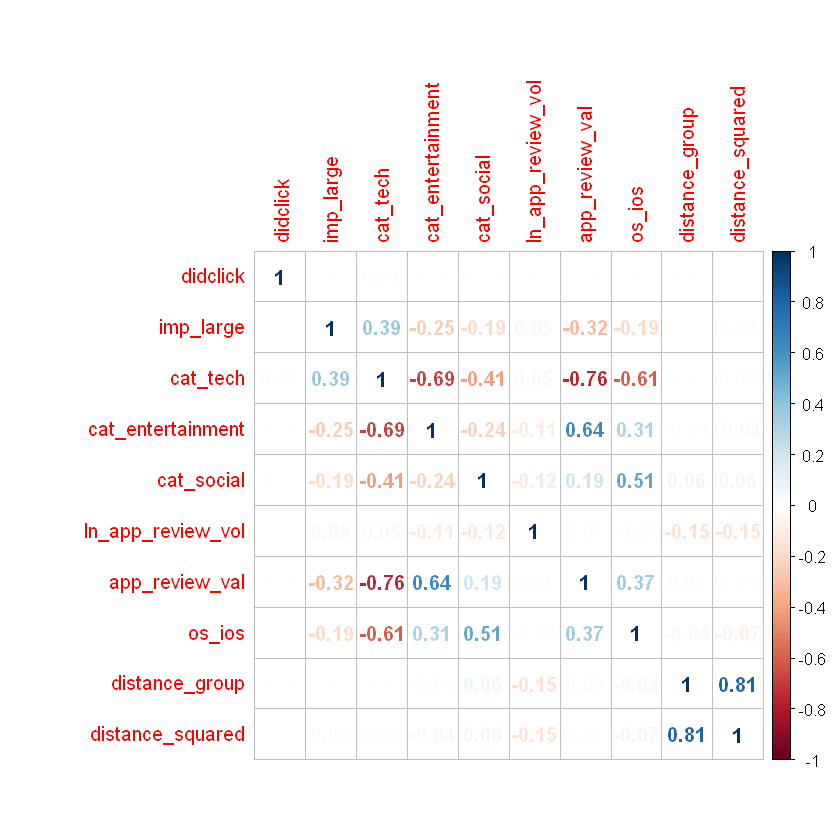

```r
corrplot(M,method="number",addrect=2)  ##circle
```

### Click Through Rate

We generate the click through rate and the click through rate considering all the impressions.

```r
click_through_rate=sum(data$didclick==1)/(sum(data$didclick==1)+sum(data$didclick==0))
print(paste("Click through rate for the advertising impression is ", round(click_through_rate,4)))
click_through_rate_percentage=click_through_rate*100
print(paste("Click through rate percentage for the advertising impression is ", round(click_through_rate,4)*100,"%"))
```

```
[1] "Click through rate for the advertising impression is  0.0068"
[1] "Click through rate percentage for the advertising impression is  0.68 %"
```

#### Click Through Rate based on Distance Group

We calculate the change in the the variation of clickthrough rate over distance groups (1-7) through the plot below.

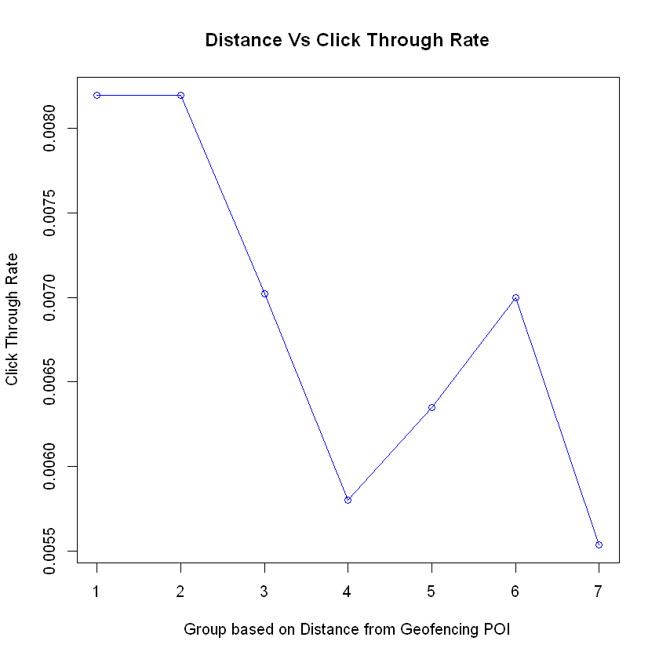

```r
data_temp=group_by(data1,distance_group)
#qplot(distance_group,summarise(data_temp, count_of_clicks=sum(didclick),click_through_rate=sum(didclick==1)/(sum(didclick==0)+sum(didclick==1))),data=data)
abc=summarise(data_temp, count_of_clicks=sum(didclick),click_through_rate=sum(didclick==1)/(sum(didclick==0)+sum(didclick==1)),impressions=n())
df = as.data.frame(abc)
plot(x=df$distance_group,y=df$click_through_rate, type = "o", col = "blue",xlab = "Group based on Distance from Geofencing POI", ylab = "Click Through Rate", main = "Distance Vs Click Through Rate")
```

#### Click Through Rate based on Distance Group Vs total Impressions for group Vs Count of didclicks

We calculate the variation in Click Through Rate based on Distance Group Vs total Impressions for group Vs Count of didclicks

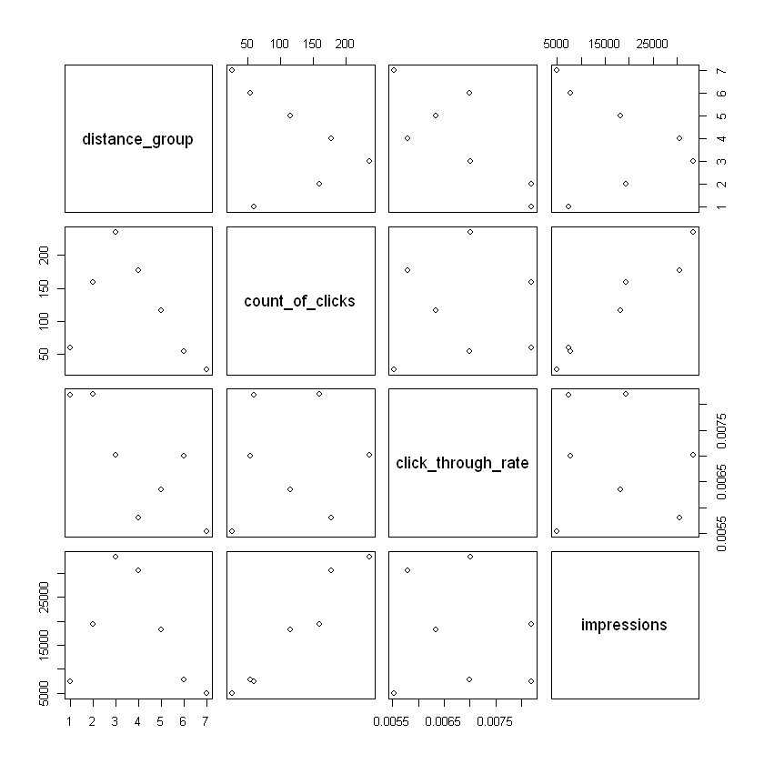

```r
plot(summarise(data_temp, count_of_clicks=sum(didclick),click_through_rate=sum(didclick==1)/(sum(didclick==0)+sum(didclick==1)),impressions=n()))
```

#### Click through Rate Vs (Device OS, Large Screen, Tech Category,Entertainment Category, Social Category, Log of application review volume, Application review value).

We generate comparision graphs to study the variation of click through rate based on predictors in the data frame such as Device OS, Large Screen, Tech Category,Entertainment Category, Social Category, Log of application review volume, Application review value

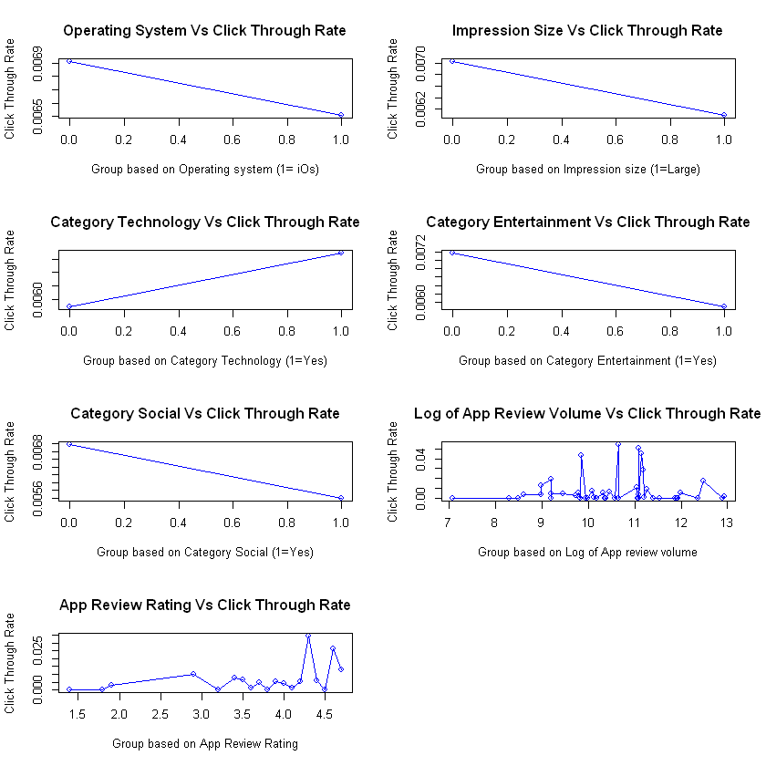

```r
par(mfrow=c(4,2))
df=as.data.frame(summarise(group_by(data1,os_ios), count_of_clicks=sum(didclick),click_through_rate=sum(didclick==1)/(sum(didclick==0)+sum(didclick==1)),impressions=n()))
plot(x=df$os_ios,y=df$click_through_rate, type = "o", col = "blue",xlab = "Group based on Operating system (1= iOs)", ylab = "Click Through Rate", main = "Operating System Vs Click Through Rate")
df=as.data.frame(summarise(group_by(data1,imp_large), count_of_clicks=sum(didclick),click_through_rate=sum(didclick==1)/(sum(didclick==0)+sum(didclick==1)),impressions=n()))
plot(x=df$imp_large,y=df$click_through_rate, type = "o", col = "blue",xlab = "Group based on Impression size (1=Large)", ylab = "Click Through Rate", main = "Impression Size Vs Click Through Rate")
df=as.data.frame(summarise(group_by(data1,cat_tech), count_of_clicks=sum(didclick),click_through_rate=sum(didclick==1)/(sum(didclick==0)+sum(didclick==1)),impressions=n()))
plot(x=df$cat_tech,y=df$click_through_rate, type = "o", col = "blue",xlab = "Group based on Category Technology (1=Yes)", ylab = "Click Through Rate", main = "Category Technology Vs Click Through Rate")
df=as.data.frame(summarise(group_by(data1,cat_entertainment), count_of_clicks=sum(didclick),click_through_rate=sum(didclick==1)/(sum(didclick==0)+sum(didclick==1)),impressions=n()))
plot(x=df$cat_entertainment,y=df$click_through_rate, type = "o", col = "blue",xlab = "Group based on Category Entertainment (1=Yes)", ylab = "Click Through Rate", main = "Category Entertainment Vs Click Through Rate")
df=as.data.frame(summarise(group_by(data1,cat_social), count_of_clicks=sum(didclick),click_through_rate=sum(didclick==1)/(sum(didclick==0)+sum(didclick==1)),impressions=n()))
plot(x=df$cat_social,y=df$click_through_rate, type = "o", col = "blue",xlab = "Group based on Category Social (1=Yes)", ylab = "Click Through Rate", main = "Category Social Vs Click Through Rate")
df=as.data.frame(summarise(group_by(data1,ln_app_review_vol), count_of_clicks=sum(didclick),click_through_rate=sum(didclick==1)/(sum(didclick==0)+sum(didclick==1)),impressions=n()))
plot(x=df$ln_app_review_vol,y=df$click_through_rate, type = "o", col = "blue",xlab = "Group based on Log of App review volume", ylab = "Click Through Rate", main = "Log of App Review Volume Vs Click Through Rate")
df=as.data.frame(summarise(group_by(data1,app_review_val), count_of_clicks=sum(didclick),click_through_rate=sum(didclick==1)/(sum(didclick==0)+sum(didclick==1)),impressions=n()))
plot(x=df$app_review_val,y=df$click_through_rate, type = "o", col = "blue",xlab = "Group based on App Review Rating", ylab = "Click Through Rate", main = "App Review Rating Vs Click Through Rate")
```

## Logistic Regression

Build a Basic Logistic Regression Model using a glm function

```r
table(data1$didclick)
glm_model_1=glm(didclick~ . ,data=data1,family = binomial)
```

```
     0      1
120739    828
```

### Summary Statistics of the Model

We generate the summary statistics of the model using the summary function. It shows that only predictors such as impression size, category of technology, the operating system of the mobile device and distance group based on distance from the geofence centre.

```r
summary(glm_model_1)
```

```
Call:
glm(formula = didclick ~ ., family = binomial, data = data1)

Deviance Residuals:
    Min       1Q   Median       3Q      Max
-0.1878  -0.1271  -0.1130  -0.1058   3.4239

Coefficients:
                   Estimate Std. Error z value Pr(>|z|)
(Intercept)       -6.797032   0.991863  -6.853 7.24e-12 ***
imp_large         -0.321867   0.091083  -3.534 0.000410 ***
cat_tech           0.778819   0.225167   3.459 0.000542 ***
cat_entertainment  0.074061   0.217002   0.341 0.732884
cat_social        -0.037635   0.248477  -0.151 0.879612
ln_app_review_vol  0.057210   0.063711   0.898 0.369206
app_review_val     0.291719   0.186310   1.566 0.117402
os_ios             0.333519   0.121010   2.756 0.005849 **
distance_group    -0.096012   0.040088  -2.395 0.016619 *
distance_squared   0.002549   0.002200   1.159 0.246523
---
Signif. codes:  0 '***' 0.001 '**' 0.01 '*' 0.05 '.' 0.1 ' ' 1

(Dispersion parameter for binomial family taken to be 1)

    Null deviance: 9912.5  on 121566  degrees of freedom
Residual deviance: 9861.5  on 121557  degrees of freedom
AIC: 9881.5

Number of Fisher Scoring iterations: 8
```

#### Model Performance Evaluation

We now evaluate the performance of the Model using a confusion Matrix.

```r
confusion_matrix(glm_model_1,DATA=data1)
```

```
Predicted levels same as naive model (majority level)
```

```
         Predicted 0
Actual 0      120739
Actual 1         828
```

The model doesn't predict any value of did click as you can see from the confusion matrix above. But the accuracy is still high since the Click through rate is only 0.0068. So we now build another model taking weights for didclick.

### GLM Model 2

```r
#data2<-data1
#data2$weight<- ifelse(data2$didclick==1,1,0.1)
#data2$weight<- 1:nrow(data2)
#glm_model_2=glm(didclick~ . ,data=data2,weights=weight,family = binomial)
#summary(glm_model_2)
```

```r
#Supersampling Rare Events in R
data_smote <- data1
data_smote$didclick <- as.factor(data_smote$didclick)
data_smote=(DMwR::SMOTE(didclick ~ ., data_smote,perc.over = 100, perc.under=200))
glm_model_2=glm(didclick~os_ios+distance_group+cat_tech+imp_large ,data=data_smote,family = binomial)
summary(glm_model_2)
```

```
Call:
glm(formula = didclick ~ os_ios + distance_group + cat_tech +
    imp_large, family = binomial, data = data_smote)

Deviance Residuals:
     Min        1Q    Median        3Q       Max
-1.42254  -1.14823   0.05907   1.18311   1.43432

Coefficients:
               Estimate Std. Error z value Pr(>|z|)
(Intercept)    -0.12964    0.12319  -1.052   0.2926
os_ios          0.25312    0.10886   2.325   0.0201 *
distance_group -0.05565    0.02426  -2.293   0.0218 *
cat_tech        0.60339    0.10067   5.994 2.05e-09 ***
imp_large      -0.37588    0.09063  -4.147 3.36e-05 ***
---
Signif. codes:  0 '***' 0.001 '**' 0.01 '*' 0.05 '.' 0.1 ' ' 1

(Dispersion parameter for binomial family taken to be 1)

    Null deviance: 4591.4  on 3311  degrees of freedom
Residual deviance: 4539.3  on 3307  degrees of freedom
AIC: 4549.3

Number of Fisher Scoring iterations: 4
```

```r
confusion_matrix(glm_model_2,DATA=data1)
```

|  | Predicted 0 | Predicted 1 | Total |
| --- | --- | --- | --- |
| Actual 0 | 72511 | 48228 | 120739 |
| Actual 1 | 418 | 410 | 828 |
| Total | 72929 | 48638 | 121567 |

We calculate the Variance Inflation Factor to ensure we are not having predictors with high multicollinearity amongst them.

```r
vif(glm_model_2)
```

**os_ios**

1.82622257409458

**distance_group**

1.00495306840887

**cat_tech**

2.017654109377

**imp_large**

1.16074889648089

We now check if the reduced model glm_model_2 fits as well as the glm_model_1 with all predictors using the chi-square value from the anova test.

```r
glm_model_1=glm(didclick~ . ,data=data_smote,family = binomial) #To ensure models are fitted to the same size of dataset
anova(glm_model_1,glm_model_2, test="Chisq")
```

[output not shown]

The non-significant Chisquare probability (p = 0.25) suggests that the reduced model fits as well as the full model

So We also plot the ROC and the AUC values for the glm model 2.

```
[1] "AUC Value is  0.574044354885762"
```

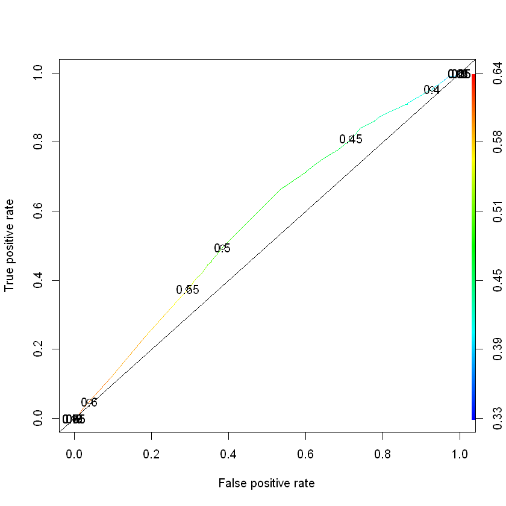

```r
prob_train <- predict(glm_model_2, type = "response")  ##List of predictions from model
pred <- prediction(prob_train, data_smote$didclick)
perf <- performance(pred, measure="tpr", x.measure="fpr")  ##Get True+ve and True_ve rate
##AUC Score
perf_auc <- performance(pred, measure="auc")
auc <- perf_auc@y.values[[1]]
print(paste("AUC Value is ",auc))   ##0.564
#ROC Curve
par(mfrow=c(1,1))
plot(perf, col=rainbow(10), colorize=T, print.cutoffs.at=seq(0,1,0.05))  ##Plot ROC Curve
abline(a=0, b= 1)
```

## Analysis of Geo Fence Radius

We are also interested in analysing the Geo Fence radius parameter if it is of any significance. So we start off by studying the variation of the geo fence radius based on Latitude and Longitude.

So we use the summarise function to study the variation of radius across different latitudes and longitudes that are grouped uniquely.

```r
data2 <- data1
data2$gepfence_radius=data_backup$gepfence_radius
data2$geofence_lon=data_backup$geofence_lon
data2$geofence_lat=data_backup$geofence_lat
data2_temp <- data2 %>%
  group_by(geofence_lon,geofence_lat) %>%
  summarise(min=min(gepfence_radius),max=max(gepfence_radius),average_radius=mean(gepfence_radius))
data2_temp
```

| geofence_lon | geofence_lat | min | max | average_radius |
| --- | --- | --- | --- | --- |
| -118.0128 | 33.84287 | 11.263 | 11.263 | 11.263 |
| -118.0128 | 33.90455 | 11.263 | 11.263 | 11.263 |
| -118.0053 | 33.84667 | 11.263 | 11.263 | 11.263 |
| -118.0000 | 33.85000 | 11.263 | 11.263 | 11.263 |
| -117.9893 | 33.87948 | 11.263 | 11.263 | 11.263 |
| -117.9659 | 33.82353 | 11.263 | 11.263 | 11.263 |
| -117.9659 | 33.87496 | 11.263 | 11.263 | 11.263 |
| -117.9635 | 33.87004 | 11.263 | 11.263 | 11.263 |
| -117.9616 | 33.81779 | 11.263 | 11.263 | 11.263 |
| -117.9600 | 33.92266 | 11.263 | 11.263 | 11.263 |
| -117.9592 | 33.91737 | 11.263 | 11.263 | 11.263 |
| -117.9542 | 33.84698 | 11.263 | 11.263 | 11.263 |
| -117.9400 | 33.84000 | 11.263 | 11.263 | 11.263 |
| -117.9373 | 33.84164 | 11.263 | 11.263 | 11.263 |
| -117.9308 | 33.87330 | 11.263 | 11.263 | 11.263 |
| -117.9308 | 33.90416 | 11.263 | 11.263 | 11.263 |
| -117.9304 | 33.89179 | 11.263 | 11.263 | 11.263 |
| -117.9275 | 33.81798 | 11.263 | 11.263 | 11.263 |
| -117.9220 | 33.87031 | 11.263 | 11.263 | 11.263 |
| -117.9202 | 33.86190 | 11.263 | 11.263 | 11.263 |
| -117.9193 | 33.81241 | 11.263 | 11.263 | 11.263 |
| -117.9168 | 33.83251 | 11.263 | 11.263 | 11.263 |
| -117.9073 | 33.82760 | 11.263 | 11.263 | 11.263 |
| -117.9026 | 33.87407 | 11.263 | 11.263 | 11.263 |
| -117.9010 | 33.81814 | 11.263 | 11.263 | 11.263 |
| -117.8956 | 33.88192 | 11.263 | 11.263 | 11.263 |
| -117.8904 | 33.91767 | 11.263 | 11.263 | 11.263 |
| -117.8839 | 33.83904 | 11.263 | 11.263 | 11.263 |
| -117.8722 | 33.83621 | 11.263 | 11.263 | 11.263 |
| -117.8635 | 33.88821 | 11.263 | 11.263 | 11.263 |
| ... | ... | ... | ... | ... |
| -88.02163 | 41.77352 | 5 | 5 | 5 |
| -88.02163 | 41.81329 | 5 | 5 | 5 |
| -88.02163 | 41.97208 | 5 | 5 | 5 |
| -88.00206 | 41.87255 | 5 | 5 | 5 |
| -88.00206 | 41.93209 | 5 | 5 | 5 |
| -87.97758 | 41.74789 | 5 | 5 | 5 |
| -87.97758 | 41.79762 | 5 | 5 | 5 |
| -87.97758 | 41.87709 | 5 | 5 | 5 |
| -87.97758 | 41.96636 | 5 | 5 | 5 |
| -87.95798 | 41.79727 | 5 | 5 | 5 |
| -87.94328 | 41.83179 | 5 | 5 | 5 |
| -87.94328 | 41.89137 | 5 | 5 | 5 |
| -87.94328 | 41.95088 | 5 | 5 | 5 |
| -87.92858 | 41.79675 | 5 | 5 | 5 |
| -87.92368 | 41.75190 | 5 | 5 | 5 |
| -87.90896 | 41.86594 | 5 | 5 | 5 |
| -87.89915 | 41.80615 | 5 | 5 | 5 |
| -87.89915 | 41.91538 | 5 | 5 | 5 |
| -87.88934 | 41.84572 | 5 | 5 | 5 |
| -87.88075 | 41.90388 | 5 | 5 | 5 |
| -87.87952 | 41.93485 | 5 | 5 | 5 |
| -87.86971 | 41.83542 | 5 | 5 | 5 |
| -87.86971 | 41.88507 | 5 | 5 | 5 |
| -87.85989 | 41.85511 | 5 | 5 | 5 |
| -87.85989 | 41.90474 | 5 | 5 | 5 |
| -87.85006 | 41.82512 | 5 | 5 | 5 |
| -87.84024 | 41.87460 | 5 | 5 | 5 |
| -87.83778 | 41.92664 | 5 | 5 | 5 |
| -87.83656 | 41.85839 | 5 | 5 | 5 |
| -87.82059 | 41.83451 | 5 | 5 | 5 |

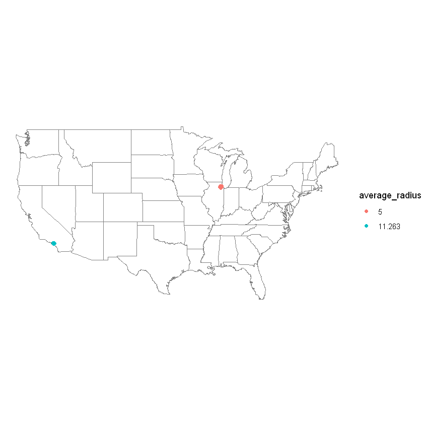

```r
data2_temp$average_radius=as.factor(data2_temp$average_radius)
data2_temp %>%
  ggplot(aes(x=geofence_lon,y=geofence_lat,fill=average_radius)) + borders("state") +geom_point(aes(colour=average_radius),size=1.5) +coord_map() +theme_void()  #Remove the theme
```

From the above graph we can infer that the red dots refer to Chicago and the blue dots refer to Los Angeles.Also, there seems to be difference in radius for the two cities of Los Angeles and Chicago. Los Angeles has a radius of 11.263 and Chicago has a radius of 5kms. So we dig more deeper into it to study if there is any change in Click Through rate based on city.

We plot the variation of Click through rate, distribution of impressions and count of clicks between the two cities.

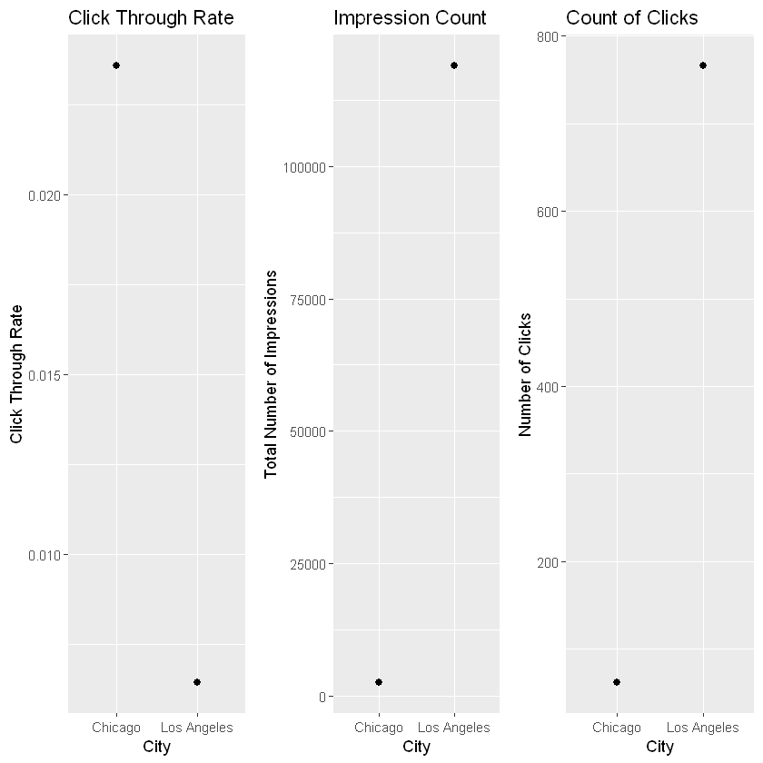

```r
data2$city<- as.factor(ifelse(data$gepfence_radius == 5,"Chicago","Los Angeles"))
df=as.data.frame(summarise(group_by(data2,city), count_of_clicks=sum(didclick==1),click_through_rate=sum(didclick==1)/(sum(didclick==0)+sum(didclick==1)),impressions=n()))
require(gridExtra)
plot1<- qplot(x=df$city,y=df$click_through_rate,size=I(2),xlab = "City", ylab = "Click Through Rate", main = "Click Through Rate")
plot2<- qplot(x=df$city,y=df$impressions,size=I(2),xlab = "City", ylab = "Total Number of Impressions", main = "Impression Count")
plot3<- qplot(x=df$city,y=df$count_of_clicks,size=I(2),xlab = "City", ylab = "Number of Clicks", main = "Count of Clicks")
gridExtra::grid.arrange(plot1, plot2,plot3, ncol=3)
```

There seems to be a significant difference in click through rate between both the cities (CTR in Chicago= 0.02359,CTR in LA=0.00644). So we are interested in learning more about it. We create a ratio attribute which denotes the normalised distance from the centre of the geo fence to understand how much the user is away from the geo fence center in terms of the radius ratio.

We define the formula as Normalised Distance = (Distance in kms)/(Radius in kms)

We also define some features based on the normalised distance as below.

```
  1. inside_quarterradius_circle as 1 if the user is inside (radius/4) size of the circle around the geo fence center.
  2. inside_halfradius_circle as 1 if the user is inside (radius/2) size of the circle around the geo fence center.
  3. outside_geofence_radius as 1 if the user is outside the circle centred around the geofence with the gepfence_radius.
```

We also study the variation of the above generated parameters.

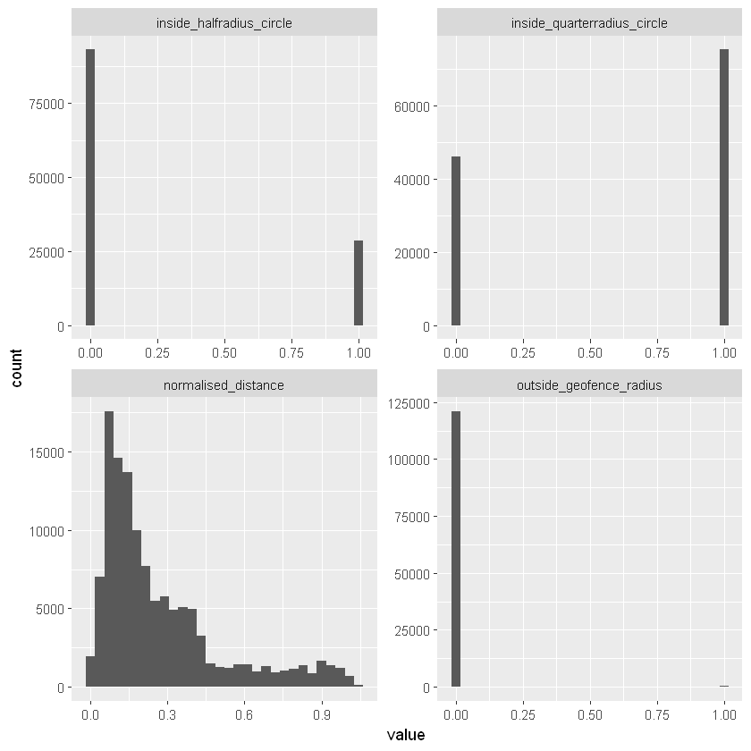

```r
data_city<- data2
data_city$normalised_distance<- sqrt(data2$distance_squared)/data2$gepfence_radius
data_city$inside_quarterradius_circle <- ifelse(data_city$normalised_distance<= 0.25,1,0)
data_city$inside_halfradius_circle <- ifelse((data_city$normalised_distance>= 0.25)&(data_city$normalised_distance<= 0.5) ,1,0)
data_city$outside_geofence_radius<- ifelse(data_city$normalised_distance>=1,1,0)

select(data_city,normalised_distance,inside_quarterradius_circle,inside_halfradius_circle,outside_geofence_radius)%>%
  gather() %>%
  ggplot(aes(value)) +
  facet_wrap(~ key, scales = "free") + scale_fill_gradient(low = "red",high = "yellow") +
  geom_histogram(bins=30) #+ facet_grid(cols = vars(key))
```

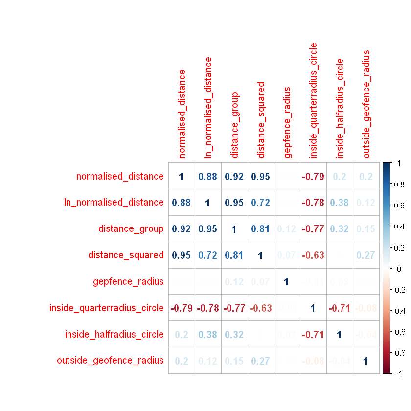

```r
data_city$ln_normalised_distance <- log(data_city$normalised_distance)
data_corr<- select(data_city,normalised_distance,ln_normalised_distance,distance_group,distance_squared,gepfence_radius,inside_quarterradius_circle,inside_halfradius_circle,outside_geofence_radius)
M<- cor(data_corr)
corrplot(M,method="number",addrect=2)  ##circle
```

```r
data_city$distance_group<- NULL
data_city$distance_squared<- NULL
data_city$gepfence_radius<- NULL
data_city$geofence_lon<- NULL
data_city$geofence_lat<- NULL
data_city$inside_halfradius_circle <- NULL
data_city$normalised_distance <- NULL
```

Now that the predictors with high correlation between them have been removed we build the model.

```r
glm_model_3=glm(didclick~ . ,data=data_city,family = binomial)
summary(glm_model_3)
```

```
Call:
glm(formula = didclick ~ ., family = binomial, data = data_city)

Deviance Residuals:
    Min       1Q   Median       3Q      Max
-0.4065  -0.1248  -0.1118  -0.1007   3.4508

Coefficients:
                            Estimate Std. Error z value Pr(>|z|)
(Intercept)                 -2.85658    0.90069  -3.172 0.001516 **
imp_large                   -0.33363    0.09162  -3.641 0.000271 ***
cat_tech                     0.88196    0.21108   4.178 2.94e-05 ***
cat_entertainment            0.11020    0.20903   0.527 0.598045
cat_social                   0.21414    0.23311   0.919 0.358296
ln_app_review_vol           -0.15414    0.06544  -2.356 0.018497 *
app_review_val               0.14257    0.16286   0.875 0.381334
os_ios                       0.14178    0.12048   1.177 0.239259
cityLos Angeles             -1.79981    0.17161 -10.488  < 2e-16 ***
inside_quarterradius_circle  0.26072    0.11828   2.204 0.027507 *
outside_geofence_radius     -0.01898    0.58461  -0.032 0.974097
ln_normalised_distance       0.03974    0.06139   0.647 0.517403
---
Signif. codes:  0 '***' 0.001 '**' 0.01 '*' 0.05 '.' 0.1 ' ' 1

(Dispersion parameter for binomial family taken to be 1)

    Null deviance: 9912.5  on 121566  degrees of freedom
Residual deviance: 9772.4  on 121555  degrees of freedom
AIC: 9796.4

Number of Fisher Scoring iterations: 8
```

The model has multiple good predictors such as presence of user inside the quarter radius circle or not, city the user is from, number of reviews for the app, the category of the app if it is technology, impression size etc.

We calculate the confusion matrix for the model.

```r
confusion_matrix(glm_model_3,DATA=data_city)
```

```
Predicted levels same as naive model (majority level)
```

```
         Predicted 0
Actual 0      120739
Actual 1         828
```

The model is not ale to predict didclicks, so we enhance the model with a SMOTE function to oversample the didclick=1 records and to only consider the significant predictors.

```r
data_smote <- data_city
data_smote$didclick <- as.factor(data_smote$didclick)
data_smote=(DMwR::SMOTE(didclick ~ ., data_smote,perc.over = 100, perc.under=200))
glm_model_4=glm(didclick~ imp_large+cat_tech+ln_app_review_vol+city+inside_quarterradius_circle ,data=data_smote,family = binomial)
summary(glm_model_4)
```

```
Call:
glm(formula = didclick ~ imp_large + cat_tech + ln_app_review_vol +
    city + inside_quarterradius_circle, family = binomial, data = data_smote)

Deviance Residuals:
    Min       1Q   Median       3Q      Max
-1.8880  -1.0917  -0.1065   1.1131   1.5949

Coefficients:
                            Estimate Std. Error z value Pr(>|z|)
(Intercept)                  2.31505    0.75952   3.048   0.0023 **
imp_large                   -0.35811    0.09158  -3.910 9.21e-05 ***
cat_tech                     0.64978    0.08089   8.033 9.55e-16 ***
ln_app_review_vol           -0.08862    0.06710  -1.321   0.1866
cityLos Angeles             -1.91764    0.20776  -9.230  < 2e-16 ***
inside_quarterradius_circle  0.15583    0.07478   2.084   0.0372 *
---
Signif. codes:  0 '***' 0.001 '**' 0.01 '*' 0.05 '.' 0.1 ' ' 1

(Dispersion parameter for binomial family taken to be 1)

    Null deviance: 4591.4  on 3311  degrees of freedom
Residual deviance: 4437.6  on 3306  degrees of freedom
AIC: 4449.6

Number of Fisher Scoring iterations: 4
```

```r
confusion_matrix(glm_model_4,DATA=data_city)
```

|  | Predicted 0 | Predicted 1 | Total |
| --- | --- | --- | --- |
| Actual 0 | 77532 | 43207 | 120739 |
| Actual 1 | 419 | 409 | 828 |
| Total | 77951 | 43616 | 121567 |

The model shows us that the parameters such as presence inside the quarterradius_circle, city details are good estimators of the didclick parameter. We also run a VIF to ensure we are not having multicollinearity in the glm model.

```r
vif(glm_model_4)
```

**imp_large**

1.16885898716684

**cat_tech**

1.24289677901265

**ln_app_review_vol**

1.1550467184951

**city**

1.20818650798882

**inside_quarterradius_circle**

1.01533280223326

We now check if the reduced model glm_model_4 fits as well as the glm_model_3 with all predictors using the chi-square value from the anova test.

```r
glm_model_3=glm(didclick~ . ,data=data_smote,family = binomial) #To ensure models are fitted to the same size of dataset
anova(glm_model_3,glm_model_4, test="Chisq")
```

| Resid. Df | Resid. Dev | Df | Deviance | Pr(>Chi) |
| --- | --- | --- | --- | --- |
| 3300 | 4432.475 | NA | NA | NA |
| 3306 | 4437.612 | -6 | -5.13713 | 0.5263495 |

So We also plot the ROC and the AUC values for the glm model 4.

```
[1] "AUC Value is  0.608094340007935"
```

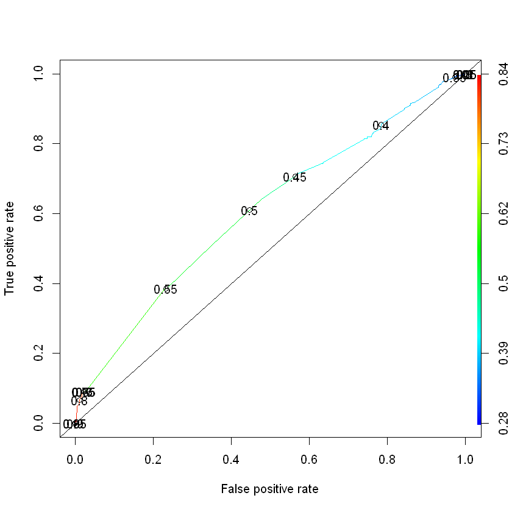

```r
prob_train <- predict(glm_model_4, type = "response")  ##List of predictions from model
pred <- prediction(prob_train, data_smote$didclick)
perf <- performance(pred, measure="tpr", x.measure="fpr")  ##Get True+ve and True_ve rate
##AUC Score
perf_auc <- performance(pred, measure="auc")
auc <- perf_auc@y.values[[1]]
print(paste("AUC Value is ",auc))   ##0.564
#ROC Curve
par(mfrow=c(1,1))
plot(perf, col=rainbow(10), colorize=T, print.cutoffs.at=seq(0,1,0.05))  ##Plot ROC Curve
abline(a=0, b= 1)
```

The AUC value for model 4 is 0.608 which is higher but similat to model 2 which has 0.57 and it also has an AIC score of 4449.6 which is lesser but similar to the AIC score of model 2 that is 4549.3. So we can conlcude that model's 2 and 4 are good since they have almost similar AIC values compared to the other models that AIC values of 9000 plus.

We now go ahead and calculate the coeffecients of the significant variables from the two glm models to derive our findings and implications.

```r
exp(coef(glm_model_2))
```

**(Intercept)**

0.878410173982329

**os_ios**

1.28803949073447

**distance_group**

0.945874364997153

**cat_tech**

1.82830842774654

**imp_large**

0.686688022847886

```r
exp(coef(glm_model_4))
```

**(Intercept)**

10.1254086266065

**imp_large**

0.698996075258733

**cat_tech**

1.91512487143457

**ln_app_review_vol**

0.915193596232614

**cityLos Angeles**

0.146952884277392

**inside_quarterradius_circle**

1.16862469096136

# Business Findings and Implications

Geofencing is a location based digital marketing technology used by advertising companies to target users with specific ads based on their proximity to local businesses. Every local business can build a geofence around it which is nothing but a circle around it for a particular radius (eg.5km) to target users that enter that particular geofence.

In this case study we are interested in finding what are the parameters that have significant impact on the click through rate and did clicks for the impressions shown to users using geofencing advertising.The overall Click through rate is 0.0068 which means about 7 people in 1,000 targeted users did click the advertisement/impression.The Descriptive Statistics and Correlation implicate that the Count of did clicks is highest for group 3 which has users who are at a radius of 1-2kms from the geo fence center or the local buiness. The number of impressions is highest for this category which shows this is one of the key areas of advertising for marketers. The click through rate is however lesser compared to group 1. Click through rate for group 1 that has users less than 0.5kms in radius has the highest click through rate.From the distributions we might want to conclude that Click through rate decreases as the Distance group increases proving distance from business is inversely propotional to the click through rate. However there is an exception for distance group 6 that we rectify using normalised distance concept.

The Category Tech has the highest correlation values with other predictors. High negative correlation with category entertainment and social, app review value and os_ios. High positive correlation with imp_large_size so we use it as a major predictor discarding all the other variables so it has a lesser VIF score.